# Data 220: Exam 2

[Mackenzie OBrien]

[Due on Tuesday November 7th at 5:00 pm (ET)]

**Load data:**

#### 1:

```r
?Boston
head(Boston)
```

```
##      crim zn indus chas   nox    rm  age    dis rad tax ptratio  black
## 1 0.00632 18  2.31    0 0.538 6.575 65.2 4.0900   1 296    15.3 396.90
## 2 0.02731  0  7.07    0 0.469 6.421 78.9 4.9671   2 242    17.8 396.90
## 3 0.02729  0  7.07    0 0.469 7.185 61.1 4.9671   2 242    17.8 392.83
## 4 0.03237  0  2.18    0 0.458 6.998 45.8 6.0622   3 222    18.7 394.63
## 5 0.06905  0  2.18    0 0.458 7.147 54.2 6.0622   3 222    18.7 396.90
## 6 0.02985  0  2.18    0 0.458 6.430 58.7 6.0622   3 222    18.7 394.12
##   lstat medv
## 1  4.98 24.0
## 2  9.14 21.6
## 3  4.03 34.7
## 4  2.94 33.4
## 5  5.33 36.2
## 6  5.21 28.7
```

There are 14 variables, and 506 rows. There are no categorical variables. The discrete variables are: chas, rad, zn, tax The continuous variables are: crim, indus, nox, rm, age, ptratio, black, lstat, medv

#### 2:

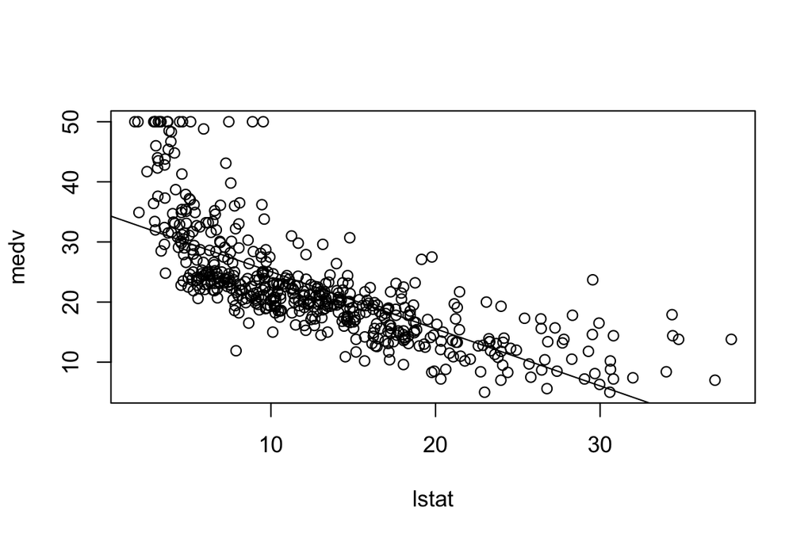

```r
attach(Boston)
plot(medv~lstat)
lmB<-lm(medv~lstat)
abline(lmB)
```

```r
summary(lmB) #linear model
```

```
##
## Call:
## lm(formula = medv ~ lstat)
##
## Residuals:
##     Min      1Q  Median      3Q     Max
## -15.168  -3.990  -1.318   2.034  24.500
##
## Coefficients:
##             Estimate Std. Error t value Pr(>|t|)
## (Intercept) 34.55384    0.56263   61.41   <2e-16 ***
## lstat       -0.95005    0.03873  -24.53   <2e-16 ***
## ---
## Signif. codes:  0 '***' 0.001 '**' 0.01 '*' 0.05 '.' 0.1 ' ' 1
##
## Residual standard error: 6.216 on 504 degrees of freedom
## Multiple R-squared:  0.5441, Adjusted R-squared:  0.5432
## F-statistic: 601.6 on 1 and 504 DF,  p-value: < 2.2e-16
```

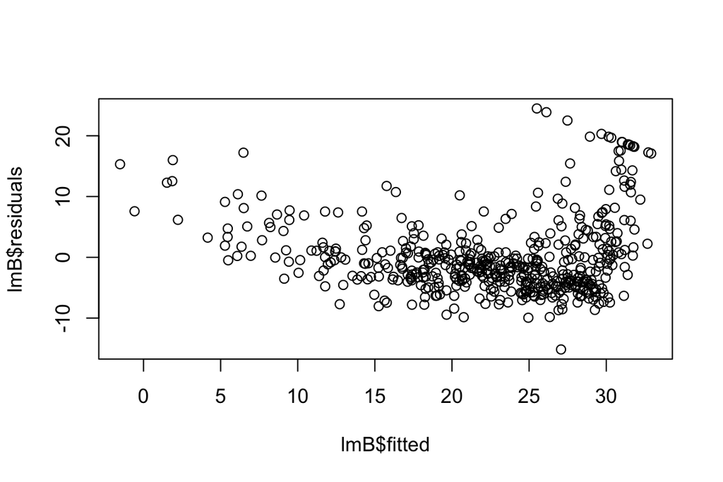

```r
plot(lmB$residuals~lmB$fitted)
```

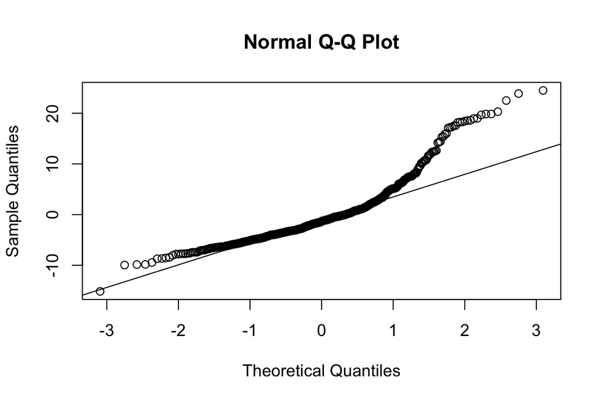

```r
qqnorm(lmB$residuals) #normal R-squared plot
qqline(lmB$residuals)
```

```r
var(lmB$residuals)
```

```
## [1] 38.55917
```

#### 3:

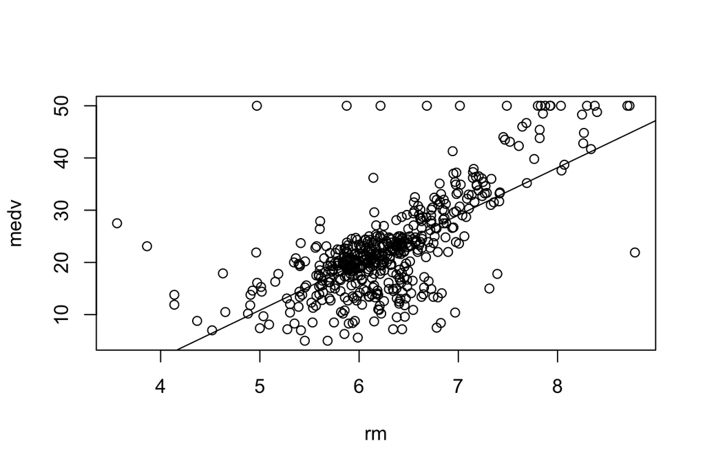

```r
plot(medv~rm)
abline(lm(medv~rm))
```

```r
cor(medv,rm)
```

```
## [1] 0.6953599
```

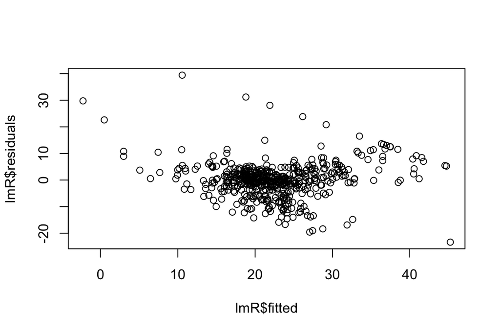

```r
lmR<-lm(medv~rm)

plot(lmR$residuals~lmR$fitted)
```

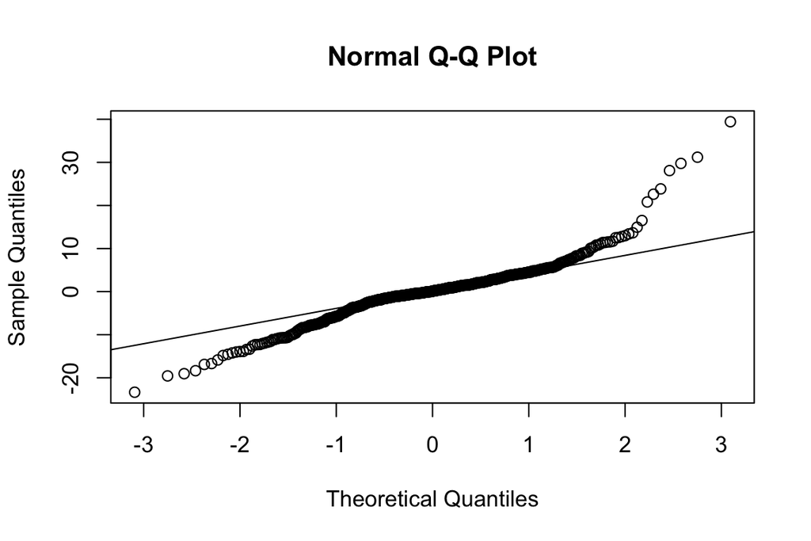

```r
qqnorm(lmR$residuals)
qqline(lmR$residuals)
```

```r
summary(lmR)
```

```
##
## Call:
## lm(formula = medv ~ rm)
##
## Residuals:
##     Min      1Q  Median      3Q     Max
## -23.346  -2.547   0.090   2.986  39.433
##
## Coefficients:
##             Estimate Std. Error t value Pr(>|t|)
## (Intercept)  -34.671      2.650  -13.08   <2e-16 ***
## rm             9.102      0.419   21.72   <2e-16 ***
## ---
## Signif. codes:  0 '***' 0.001 '**' 0.01 '*' 0.05 '.' 0.1 ' ' 1
##
## Residual standard error: 6.616 on 504 degrees of freedom
## Multiple R-squared:  0.4835, Adjusted R-squared:  0.4825
## F-statistic: 471.8 on 1 and 504 DF,  p-value: < 2.2e-16
```

```r
anova(lmR)
```

```
## Analysis of Variance Table
##
## Response: medv
##            Df Sum Sq Mean Sq F value    Pr(>F)
## rm          1  20654 20654.4  471.85 < 2.2e-16 ***
## Residuals 504  22062    43.8
## ---
## Signif. codes:  0 '***' 0.001 '**' 0.01 '*' 0.05 '.' 0.1 ' ' 1
```

#### 4:

Based on the line, the value should be about 10. The prediction gives us a value of 10.83992. The prediction is slightly overestimating the value. The residual would be -0.83992, since it is actual - predicted

```r
#pick a number from rm and use linear regression to predict the corresponding medv value. Is it over/underestimating the true value, what is the residual.
pred=data.frame(rm=5)
predicted=predict(lmR,pred)
predicted
```

```
##        1
## 10.83992
```

#### 5:

PlantGrowth is comparing yields of dried plant weights based on a control and two different treatments. There are three levels, ctrl, trt1, and trt2 for PlantGrowth$group.

```r
#Describe ?PlantGrowth. Is PlantGrowth$group a factor variable. How many levels are there?
?PlantGrowth
detach(Boston)
attach(PlantGrowth)
group
```

```
##  [1] ctrl ctrl ctrl ctrl ctrl ctrl ctrl ctrl ctrl ctrl trt1 trt1 trt1 trt1
## [15] trt1 trt1 trt1 trt1 trt1 trt1 trt2 trt2 trt2 trt2 trt2 trt2 trt2 trt2
## [29] trt2 trt2
## Levels: ctrl trt1 trt2
```

#### 6:

If you want to the margin of error to be 1%, the larger the sample size, the less the margin of error, since it is more likely that the true value is in the range. Since the interval is 95%, the sample size would need to be about 95/96.

```r
#95% confidence interval for the mean of the weight. If we want the margin of error to be 1%, what should the sample size be?
load(url("http://foxweb.marist.edu/users/duy.nguyen2/inference.RData"))
inference(y = weight, est = "mean", type = "ci", null = 0, alternative = "twosided", method = "theoretical", conflevel = 0.95)
```

```
## Single mean
## Summary statistics:
```

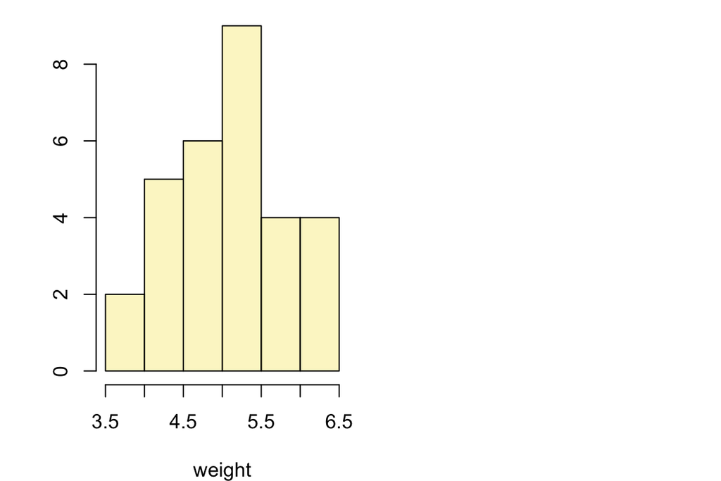

```
## mean = 5.073 ;  sd = 0.7012 ;  n = 30
## Standard error = 0.128
## 95 % Confidence interval = ( 4.8221 , 5.3239 )
```

```r
phat=mean(weight)
n=96
z.value=qnorm((1-0.95)/2)
z.value
```

```
## [1] -1.959964
```

```r
ME=z.value*phat/sqrt(n)
ME
```

```
## [1] -1.014793
```

#### 7:

It does not appear the the three groups will have the same mean since the boxplot shows that the trt2 group has the highest median, followed by the ctrl and then the trt1 group. Trt3 also has a very small range in which it matches up with ctrl and trt1, so it is unlikely that that will match.

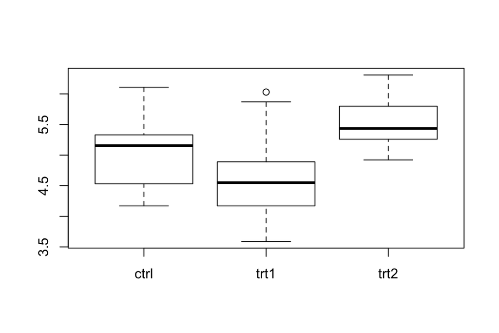

```r
#Boxplot of weight based on group. Does it appear that the three groups will have the same mean? Explain
boxplot(weight~group)
```

#### 8:

The p-value of this test also is below 0.05, causing us to also reject the null hypothesis when using this function. This means that the means are not the same.

```r
#Use the analysis of variance to test whether the three groups have the same mean. Is the test significant? why/why not. Support using graphical/numerical methods.
results=aov(weight~group,data=PlantGrowth)
summary(results)
```

```
##             Df Sum Sq Mean Sq F value Pr(>F)
## group        2  3.766  1.8832   4.846 0.0159 *
## Residuals   27 10.492  0.3886
## ---
## Signif. codes:  0 '***' 0.001 '**' 0.01 '*' 0.05 '.' 0.1 ' ' 1
```

#### 9:

```r
#which groups have different means/ Support
aggregate(weight~group, PlantGrowth,mean)
```

```
##   group weight
## 1  ctrl  5.032
## 2  trt1  4.661
## 3  trt2  5.526
```

```r
pairwise.t.test(weight,group, p.adj="bonferroni")
```

```
##
##  Pairwise comparisons using t tests with pooled SD
##
## data:  weight and group
##
##      ctrl  trt1
## trt1 0.583 -
## trt2 0.263 0.013
##
## P value adjustment method: bonferroni
```